# 26__zadanie_domowe__modul_4_2__v2

[figure not shown]

## O Danych

Dane o pasażerach Titanica

Zbiór danych zawiera informacje o pasażerach RMS Titanic, który zatonął 15 kwietnia 1912 roku po zderzeniu z górą lodową. Dane obejmują takie atrybuty jak klasa podróży, wiek, płeć, liczba rodzeństwa/małżonków na pokładzie, liczba rodziców/dzieci na pokładzie, cena biletu oraz miejsce zaokrętowania.

Zbiór zawiera także informację o tym, czy pasażer przeżył katastrofę.

Titanic przewoził ponad 2,200 osób, z czego ponad 1,500 zginęło, co czyni tę katastrofę jedną z najbardziej tragicznych w historii morskiej.

Kolumny:

- **pclass** - Klasa biletu
- **survived** - Czy pasażer przeżył katastrofę
- **name** - Imię i nazwisko pasażera
- **sex** - Płeć pasażera
- **age** - Wiek pasażera
- **sibsp** - Liczba rodzeństwa/małżonków na pokładzie
- **parch** - Liczba rodziców/dzieci na pokładzie
- **ticket** - Numer biletu
- **fare** - Cena biletu
- **cabin** - Numer kabiny
- **embarked** - Port, w którym pasażer wszedł na pokład (C = Cherbourg, Q = Queenstown, S = Southampton)
- **boat** - Numer łodzi ratunkowej
- **body** - Numer ciała (jeśli pasażer nie przeżył i ciało zostało odnalezione)
- **home.dest** - Miejsce docelowe

```python
import pandas as pd
```

```python
df = pd.read_csv('26__titanic.csv', sep=",")
df
```

|  | pclass | survived | name | sex | age | sibsp | parch | ticket | fare | cabin | embarked | boat | body | home.dest |
| --- | --- | --- | --- | --- | --- | --- | --- | --- | --- | --- | --- | --- | --- | --- |
| 0 | 1.0 | 1.0 | Allen, Miss. Elisabeth Walton | female | 29.0000 | 0.0 | 0.0 | 24160 | 211.3375 | B5 | S | 2 | NaN | St Louis, MO |
| 1 | 1.0 | 1.0 | Allison, Master. Hudson Trevor | male | 0.9167 | 1.0 | 2.0 | 113781 | 151.5500 | C22 C26 | S | 11 | NaN | Montreal, PQ / Chesterville, ON |
| 2 | 1.0 | 0.0 | Allison, Miss. Helen Loraine | female | 2.0000 | 1.0 | 2.0 | 113781 | 151.5500 | C22 C26 | S | NaN | NaN | Montreal, PQ / Chesterville, ON |
| 3 | 1.0 | 0.0 | Allison, Mr. Hudson Joshua Creighton | male | 30.0000 | 1.0 | 2.0 | 113781 | 151.5500 | C22 C26 | S | NaN | 135.0 | Montreal, PQ / Chesterville, ON |
| 4 | 1.0 | 0.0 | Allison, Mrs. Hudson J C (Bessie Waldo Daniels) | female | 25.0000 | 1.0 | 2.0 | 113781 | 151.5500 | C22 C26 | S | NaN | NaN | Montreal, PQ / Chesterville, ON |
| ... | ... | ... | ... | ... | ... | ... | ... | ... | ... | ... | ... | ... | ... | ... |
| 1305 | 3.0 | 0.0 | Zabour, Miss. Thamine | female | NaN | 1.0 | 0.0 | 2665 | 14.4542 | NaN | C | NaN | NaN | NaN |
| 1306 | 3.0 | 0.0 | Zakarian, Mr. Mapriededer | male | 26.5000 | 0.0 | 0.0 | 2656 | 7.2250 | NaN | C | NaN | 304.0 | NaN |
| 1307 | 3.0 | 0.0 | Zakarian, Mr. Ortin | male | 27.0000 | 0.0 | 0.0 | 2670 | 7.2250 | NaN | C | NaN | NaN | NaN |
| 1308 | 3.0 | 0.0 | Zimmerman, Mr. Leo | male | 29.0000 | 0.0 | 0.0 | 315082 | 7.8750 | NaN | S | NaN | NaN | NaN |
| 1309 | NaN | NaN | NaN | NaN | NaN | NaN | NaN | NaN | NaN | NaN | NaN | NaN | NaN | NaN |

1310 rows × 14 columns

# Ogólny przegląd danych pliku CSV.

```python
df.info() # wyświetlenie ogólnych informacji zawartych w pliku
```

```
<class 'pandas.core.frame.DataFrame'>
RangeIndex: 1310 entries, 0 to 1309
Data columns (total 14 columns):
 #   Column     Non-Null Count  Dtype
---  ------     --------------  -----
 0   pclass     1309 non-null   float64
 1   survived   1309 non-null   float64
 2   name       1309 non-null   object
 3   sex        1309 non-null   object
 4   age        1046 non-null   float64
 5   sibsp      1309 non-null   float64
 6   parch      1309 non-null   float64
 7   ticket     1309 non-null   object
 8   fare       1308 non-null   float64
 9   cabin      295 non-null    object
 10  embarked   1307 non-null   object
 11  boat       486 non-null    object
 12  body       121 non-null    float64
 13  home.dest  745 non-null    object
dtypes: float64(7), object(7)
memory usage: 143.4+ KB
```

```python
df.columns # wyświetlenie informacji o kolumnach
```

```
Index(['pclass', 'survived', 'name', 'sex', 'age', 'sibsp', 'parch', 'ticket',
       'fare', 'cabin', 'embarked', 'boat', 'body', 'home.dest'],
      dtype='object')
```

```python
df.index # wyświetlenie informacji o indeksie
```

```
RangeIndex(start=0, stop=1310, step=1)
```

```python
df.head(10) # wyświetlenie 10 początkowych wartości
```

|  | pclass | survived | name | sex | age | sibsp | parch | ticket | fare | cabin | embarked | boat | body | home.dest |
| --- | --- | --- | --- | --- | --- | --- | --- | --- | --- | --- | --- | --- | --- | --- |
| 0 | 1.0 | 1.0 | Allen, Miss. Elisabeth Walton | female | 29.0000 | 0.0 | 0.0 | 24160 | 211.3375 | B5 | S | 2 | NaN | St Louis, MO |
| 1 | 1.0 | 1.0 | Allison, Master. Hudson Trevor | male | 0.9167 | 1.0 | 2.0 | 113781 | 151.5500 | C22 C26 | S | 11 | NaN | Montreal, PQ / Chesterville, ON |
| 2 | 1.0 | 0.0 | Allison, Miss. Helen Loraine | female | 2.0000 | 1.0 | 2.0 | 113781 | 151.5500 | C22 C26 | S | NaN | NaN | Montreal, PQ / Chesterville, ON |
| 3 | 1.0 | 0.0 | Allison, Mr. Hudson Joshua Creighton | male | 30.0000 | 1.0 | 2.0 | 113781 | 151.5500 | C22 C26 | S | NaN | 135.0 | Montreal, PQ / Chesterville, ON |
| 4 | 1.0 | 0.0 | Allison, Mrs. Hudson J C (Bessie Waldo Daniels) | female | 25.0000 | 1.0 | 2.0 | 113781 | 151.5500 | C22 C26 | S | NaN | NaN | Montreal, PQ / Chesterville, ON |
| 5 | 1.0 | 1.0 | Anderson, Mr. Harry | male | 48.0000 | 0.0 | 0.0 | 19952 | 26.5500 | E12 | S | 3 | NaN | New York, NY |
| 6 | 1.0 | 1.0 | Andrews, Miss. Kornelia Theodosia | female | 63.0000 | 1.0 | 0.0 | 13502 | 77.9583 | D7 | S | 10 | NaN | Hudson, NY |
| 7 | 1.0 | 0.0 | Andrews, Mr. Thomas Jr | male | 39.0000 | 0.0 | 0.0 | 112050 | 0.0000 | A36 | S | NaN | NaN | Belfast, NI |
| 8 | 1.0 | 1.0 | Appleton, Mrs. Edward Dale (Charlotte Lamson) | female | 53.0000 | 2.0 | 0.0 | 11769 | 51.4792 | C101 | S | D | NaN | Bayside, Queens, NY |
| 9 | 1.0 | 0.0 | Artagaveytia, Mr. Ramon | male | 71.0000 | 0.0 | 0.0 | PC 17609 | 49.5042 | NaN | C | NaN | 22.0 | Montevideo, Uruguay |

```python
df.tail(10) # wyświetlenie 10 końcowych wartości
```

|  | pclass | survived | name | sex | age | sibsp | parch | ticket | fare | cabin | embarked | boat | body | home.dest |
| --- | --- | --- | --- | --- | --- | --- | --- | --- | --- | --- | --- | --- | --- | --- |
| 1300 | 3.0 | 1.0 | Yasbeck, Mrs. Antoni (Selini Alexander) | female | 15.0 | 1.0 | 0.0 | 2659 | 14.4542 | NaN | C | NaN | NaN | NaN |
| 1301 | 3.0 | 0.0 | Youseff, Mr. Gerious | male | 45.5 | 0.0 | 0.0 | 2628 | 7.2250 | NaN | C | NaN | 312.0 | NaN |
| 1302 | 3.0 | 0.0 | Yousif, Mr. Wazli | male | NaN | 0.0 | 0.0 | 2647 | 7.2250 | NaN | C | NaN | NaN | NaN |
| 1303 | 3.0 | 0.0 | Yousseff, Mr. Gerious | male | NaN | 0.0 | 0.0 | 2627 | 14.4583 | NaN | C | NaN | NaN | NaN |
| 1304 | 3.0 | 0.0 | Zabour, Miss. Hileni | female | 14.5 | 1.0 | 0.0 | 2665 | 14.4542 | NaN | C | NaN | 328.0 | NaN |
| 1305 | 3.0 | 0.0 | Zabour, Miss. Thamine | female | NaN | 1.0 | 0.0 | 2665 | 14.4542 | NaN | C | NaN | NaN | NaN |
| 1306 | 3.0 | 0.0 | Zakarian, Mr. Mapriededer | male | 26.5 | 0.0 | 0.0 | 2656 | 7.2250 | NaN | C | NaN | 304.0 | NaN |
| 1307 | 3.0 | 0.0 | Zakarian, Mr. Ortin | male | 27.0 | 0.0 | 0.0 | 2670 | 7.2250 | NaN | C | NaN | NaN | NaN |
| 1308 | 3.0 | 0.0 | Zimmerman, Mr. Leo | male | 29.0 | 0.0 | 0.0 | 315082 | 7.8750 | NaN | S | NaN | NaN | NaN |
| 1309 | NaN | NaN | NaN | NaN | NaN | NaN | NaN | NaN | NaN | NaN | NaN | NaN | NaN | NaN |

```python
df.sample(15) # wyświetlenie 15 losowych wartości
```

|  | pclass | survived | name | sex | age | sibsp | parch | ticket | fare | cabin | embarked | boat | body | home.dest |
| --- | --- | --- | --- | --- | --- | --- | --- | --- | --- | --- | --- | --- | --- | --- |
| 608 | 3.0 | 0.0 | Adahl, Mr. Mauritz Nils Martin | male | 30.0 | 0.0 | 0.0 | C 7076 | 7.2500 | NaN | S | NaN | 72.0 | Asarum, Sweden Brooklyn, NY |
| 1214 | 3.0 | 0.0 | Smiljanic, Mr. Mile | male | NaN | 0.0 | 0.0 | 315037 | 8.6625 | NaN | S | NaN | NaN | NaN |
| 322 | 1.0 | 1.0 | Young, Miss. Marie Grice | female | 36.0 | 0.0 | 0.0 | PC 17760 | 135.6333 | C32 | C | 8 | NaN | New York, NY / Washington, DC |
| 817 | 3.0 | 0.0 | Gilinski, Mr. Eliezer | male | 22.0 | 0.0 | 0.0 | 14973 | 8.0500 | NaN | S | NaN | 47.0 | NaN |
| 1098 | 3.0 | 0.0 | Palsson, Miss. Stina Viola | female | 3.0 | 3.0 | 1.0 | 349909 | 21.0750 | NaN | S | NaN | NaN | NaN |
| 740 | 3.0 | 0.0 | Culumovic, Mr. Jeso | male | 17.0 | 0.0 | 0.0 | 315090 | 8.6625 | NaN | S | NaN | NaN | Austria-Hungary |
| 376 | 2.0 | 1.0 | Collett, Mr. Sidney C Stuart | male | 24.0 | 0.0 | 0.0 | 28034 | 10.5000 | NaN | S | 9 | NaN | London / Fort Byron, NY |
| 863 | 3.0 | 0.0 | Hendekovic, Mr. Ignjac | male | 28.0 | 0.0 | 0.0 | 349243 | 7.8958 | NaN | S | NaN | 306.0 | NaN |
| 996 | 3.0 | 0.0 | Markun, Mr. Johann | male | 33.0 | 0.0 | 0.0 | 349257 | 7.8958 | NaN | S | NaN | NaN | NaN |
| 570 | 2.0 | 1.0 | Toomey, Miss. Ellen | female | 50.0 | 0.0 | 0.0 | F.C.C. 13531 | 10.5000 | NaN | S | 9 | NaN | Indianapolis, IN |
| 652 | 3.0 | 0.0 | Augustsson, Mr. Albert | male | 23.0 | 0.0 | 0.0 | 347468 | 7.8542 | NaN | S | NaN | NaN | Krakoryd, Sweden Bloomington, IL |
| 1247 | 3.0 | 1.0 | Thorneycroft, Mrs. Percival (Florence Kate White) | female | NaN | 1.0 | 0.0 | 376564 | 16.1000 | NaN | S | 10 | NaN | NaN |
| 814 | 3.0 | 0.0 | Gallagher, Mr. Martin | male | 25.0 | 0.0 | 0.0 | 36864 | 7.7417 | NaN | Q | NaN | NaN | New York, NY |
| 730 | 3.0 | 0.0 | Cor, Mr. Ivan | male | 27.0 | 0.0 | 0.0 | 349229 | 7.8958 | NaN | S | NaN | NaN | Austria |
| 1022 | 3.0 | 0.0 | Mitkoff, Mr. Mito | male | NaN | 0.0 | 0.0 | 349221 | 7.8958 | NaN | S | NaN | NaN | NaN |

```python
df.nunique() # wyświetlenie unikatowych wartości w kolumnach
```

```
pclass          3
survived        2
name         1307
sex             2
age            98
sibsp           7
parch           8
ticket        929
fare          281
cabin         186
embarked        3
boat           27
body          121
home.dest     369
dtype: int64
```

```python
df.describe() # wyświetlenie statystyk dla kolumn numerycznych
```

|  | pclass | survived | age | sibsp | parch | fare | body |
| --- | --- | --- | --- | --- | --- | --- | --- |
| count | 1309.000000 | 1309.000000 | 1046.000000 | 1309.000000 | 1309.000000 | 1308.000000 | 121.000000 |
| mean | 2.294882 | 0.381971 | 29.881135 | 0.498854 | 0.385027 | 33.295479 | 160.809917 |
| std | 0.837836 | 0.486055 | 14.413500 | 1.041658 | 0.865560 | 51.758668 | 97.696922 |
| min | 1.000000 | 0.000000 | 0.166700 | 0.000000 | 0.000000 | 0.000000 | 1.000000 |
| 25% | 2.000000 | 0.000000 | 21.000000 | 0.000000 | 0.000000 | 7.895800 | 72.000000 |
| 50% | 3.000000 | 0.000000 | 28.000000 | 0.000000 | 0.000000 | 14.454200 | 155.000000 |
| 75% | 3.000000 | 1.000000 | 39.000000 | 1.000000 | 0.000000 | 31.275000 | 256.000000 |
| max | 3.000000 | 1.000000 | 80.000000 | 8.000000 | 9.000000 | 512.329200 | 328.000000 |

### Pierwsze ogólne obserwacje.

##### Dane zawierają informację o pasażerach statku Titanic. Dane zawierają 14 kolumn m.in.: klasa podróży, wiek, płeć, liczba rodzeństwa/małżonków na pokładzie, liczba rodziców/dzieci na pokładzie, cena biletu, miejsce zaokrętowania, czy pasażer przeżył katastrtofę. Dane składają się z 1310 wartości.

# Analiza brakujących wartości.

```python
df.count() # wyświetlenie sumy wartości w kolumnach
```

```
pclass       1309
survived     1309
name         1309
sex          1309
age          1046
sibsp        1309
parch        1309
ticket       1309
fare         1308
cabin         295
embarked     1307
boat          486
body          121
home.dest     745
dtype: int64
```

```python
df.isnull().sum() # wyświetlenie sumy brakujących wartości dla każdej kolumny
```

```
pclass          1
survived        1
name            1
sex             1
age           264
sibsp           1
parch           1
ticket          1
fare            2
cabin        1015
embarked        3
boat          824
body         1189
home.dest     565
dtype: int64
```

```python
df[df.duplicated()] # wyświetlenie duplicatów w postaci tabeli
```

|  | pclass | survived | name | sex | age | sibsp | parch | ticket | fare | cabin | embarked | boat | body | home.dest |
| --- | --- | --- | --- | --- | --- | --- | --- | --- | --- | --- | --- | --- | --- | --- |

```python
df.duplicated() # wyświetlenie duplikatów w postaci boolean
```

```
0       False
1       False
2       False
3       False
4       False
        ...
1305    False
1306    False
1307    False
1308    False
1309    False
Length: 1310, dtype: bool
```

### Krótkie obserwacje.

##### W pliku CSV z danymi znajdują się brakujące wartości. Najwięcej danych brakuje w takich kolumnach jak: numer ciała, numer cabiny, numer łodzi ratunkowej, miejsce docelowe, wiek. Dane nie zawierają duplikatów.

# Analiza poszczególnych zmiennych.

```
array([[<Axes: title={'center': 'pclass'}>,
        <Axes: title={'center': 'survived'}>,
        <Axes: title={'center': 'age'}>],
       [<Axes: title={'center': 'sibsp'}>,
        <Axes: title={'center': 'parch'}>,
        <Axes: title={'center': 'fare'}>],
       [<Axes: title={'center': 'body'}>, <Axes: >, <Axes: >]],
      dtype=object)
```

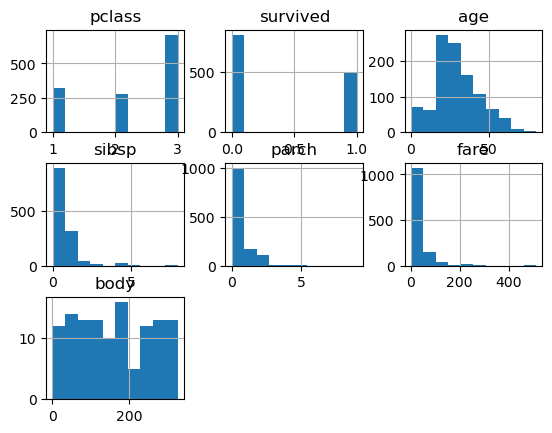

```python
df.hist() # wyświetlenie histogramu dla wartości numerycznych
```

```python
df_cleaned = df.dropna(subset=['sex']) # usunięcie wierszy z brakującymi danymi
df.groupby('sex',as_index=False)
sex_counts = df['sex'].value_counts()
sex_counts
```

```
male      843
female    466
Name: sex, dtype: int64
```

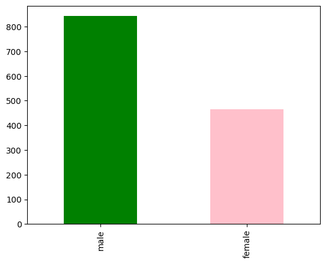

```python
sex_counts.plot(kind='bar',color=['green', 'pink']) # wizualizacja liczby kobiet i mężczyzn na wykresie
```

```python
df_cleaned = df.dropna(subset=['sex', 'survived'])
survived_by_sex = df[df['survived'] == 1].groupby('sex').size()
survived_by_sex # wyświetlenie ilości kobiet i mężczyzn, którzy przeżyli
```

```
sex
female    339
male      161
dtype: int64
```

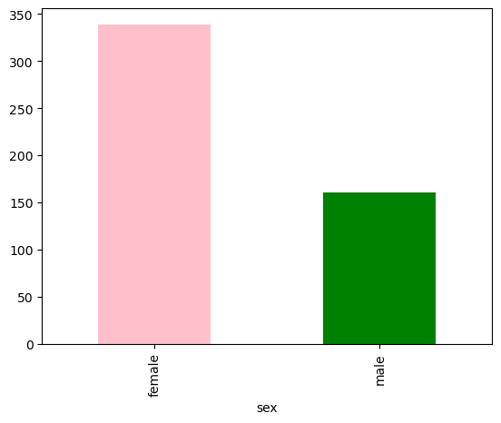

```python
survived_by_sex.plot(kind='bar', color=['pink', 'green'])
```

##### Według danych, które analizujemy 1310 rekordów, na statku było więcej mężczyzn-843, kobiet-466, natomiast przeżyło 339 kobiet i 161 mężczyzn.

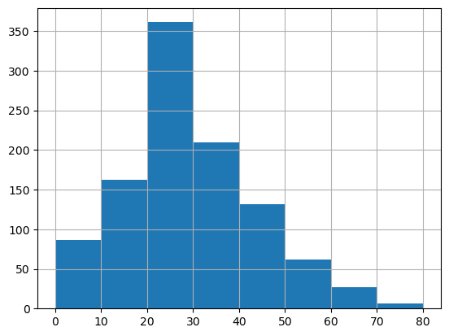

```python
df_cleaned = df.dropna(subset=['age']) # usunięcie wierszy z brakującymi danymi
df['age'].hist(bins=8) # wizualizacja na histagramie wieku pasażerów statku
```

```python
survived_passengers=df[df['survived'] == 1]
youngest_survivor_age = survived_passengers['age'].min()
oldest_survivor_age = survived_passengers['age'].max()
```

```python
oldest_survivor_age # wyświetlenie ile lat miał najstarszy pasażer
```

```
80.0
```

```python
youngest_survivor_age # wyświetlenie ile lat miał najmłodszy pasażer
```

```
0.1667
```

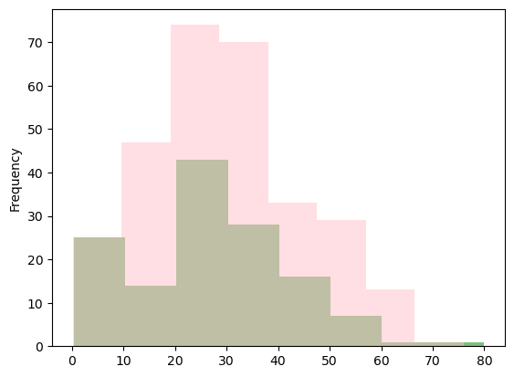

```python
df_cleaned = df.dropna(subset=['sex','age','survived'])
survivors = df[df['survived'] == 1]
male_survivors = survivors[survivors['sex'] == 'male']
female_survivors = survivors[survivors['sex'] == 'female']
male_survivors['age'].plot(kind='hist',bins=8,alpha=0.5,label='Male Survivors', color='green') # wizualizacja w jakim wieku byli pasażerowi, którzy przeżyli
female_survivors['age'].plot(kind='hist',bins=8,alpha=0.5,label='Female Survivors', color='pink') # wizualizacja z podziałem na płeć
```

##### Najwięcej pasażerów mieściła się w przedziale wiekowym 20-30 lat. Najmłodszy pasażer nie osiągnął nawet roku, a najstarszy pasażer miał 80 lat, znaleźli sie oni w grupie ocalałych. Najwięcej kobiet, które przeżyły mieściły się w grupie wiekowej 20-40 lat, z kolei ocalali mężczyźni to wiek 20-30 lat.

```python
df_cleaned = df.dropna(subset=['pclass', 'survived']) # usunięcie brakujacy wartości
survived_by_class = df_cleaned.groupby('pclass')['survived'].sum()
survived_by_class # wyświetlenie ocalałych biorąc pod uwagę klasę biletu
```

```
pclass
1.0    200.0
2.0    119.0
3.0    181.0
Name: survived, dtype: float64
```

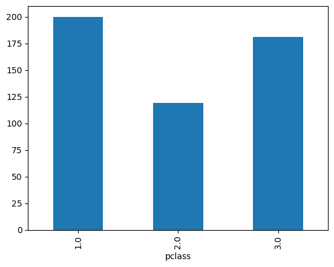

```python
survived_by_class.plot(kind='bar') #wizualizacja na wykresie
```

```python
df['fare'].describe() # wyświetlenie statystyk dla kolumny-cena biletu
```

```
count    1308.000000
mean       33.295479
std        51.758668
min         0.000000
25%         7.895800
50%        14.454200
75%        31.275000
max       512.329200
Name: fare, dtype: float64
```

##### Najwięcej spośród ocalałych osób posiadało pierwszą klasę biletu. Statystyki cen biletów wskazują na duże zróżnicowanie w cenie. Średnia cena biletu - 33,29 £.

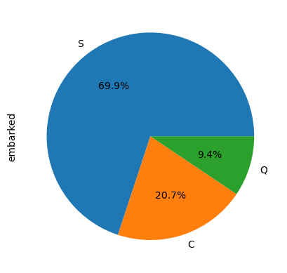

```python
df['embarked'].value_counts().plot.pie(autopct='%1.1f%%') # wizualizacja na wykresie kołowym ilości pasażerów na poszczególnych portach
```

##### Najwięcej pasażerów wsiadło na pokład statku w porcie Southampton.

```python
boat_counts=df['boat'].value_counts()
boat_counts # wyświetlenie ilości łodzi ratunkowych
```

```
13         39
C          38
15         37
14         33
4          31
10         29
5          27
3          26
9          25
11         25
16         23
8          23
7          23
D          20
6          20
12         19
2          13
A          11
B           9
1           5
5 7         2
C D         2
13 15       2
5 9         1
8 10        1
13 15 B     1
15 16       1
Name: boat, dtype: int64
```

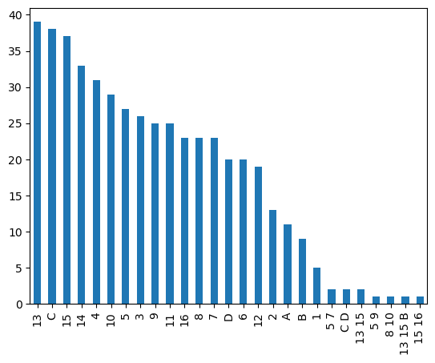

```python
boat_counts.plot(kind='bar') #wizualizacja ilości pasażerów w łodziach ratunkowych
```

##### Ilość pasażerów w łodziach ratunkowych jest nierównomierna. W wielu łodziach płynęło tylko kilka osób.

# Analiza relacji między zmiennymi.

```python
df.corr() # wyświetlenie macierza korleracji
```

|  | pclass | survived | age | sibsp | parch | fare | body |
| --- | --- | --- | --- | --- | --- | --- | --- |
| pclass | 1.000000 | -0.312469 | -0.408106 | 0.060832 | 0.018322 | -0.558629 | -0.034642 |
| survived | -0.312469 | 1.000000 | -0.055513 | -0.027825 | 0.082660 | 0.244265 | NaN |
| age | -0.408106 | -0.055513 | 1.000000 | -0.243699 | -0.150917 | 0.178739 | 0.058809 |
| sibsp | 0.060832 | -0.027825 | -0.243699 | 1.000000 | 0.373587 | 0.160238 | -0.099961 |
| parch | 0.018322 | 0.082660 | -0.150917 | 0.373587 | 1.000000 | 0.221539 | 0.051099 |
| fare | -0.558629 | 0.244265 | 0.178739 | 0.160238 | 0.221539 | 1.000000 | -0.043110 |
| body | -0.034642 | NaN | 0.058809 | -0.099961 | 0.051099 | -0.043110 | 1.000000 |

```python
df[['pclass','age', 'survived']].corr()
```

|  | pclass | age | survived |
| --- | --- | --- | --- |
| pclass | 1.000000 | -0.408106 | -0.312469 |
| age | -0.408106 | 1.000000 | -0.055513 |
| survived | -0.312469 | -0.055513 | 1.000000 |

# Analiza wartości odstających.

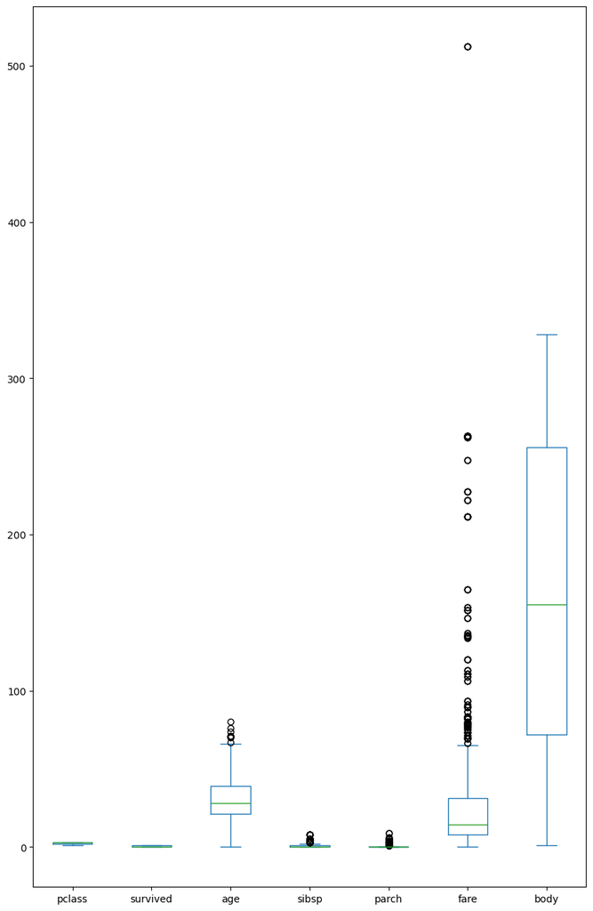

```python
df.plot(kind='box',figsize=(10, 16)) # wyświetlenie boxplot dla wartości numerycznych
```

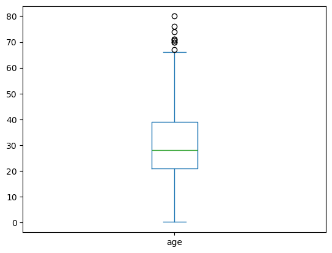

```python
df['age'].plot(kind='box') # boxplot dla kolumny wiek
```

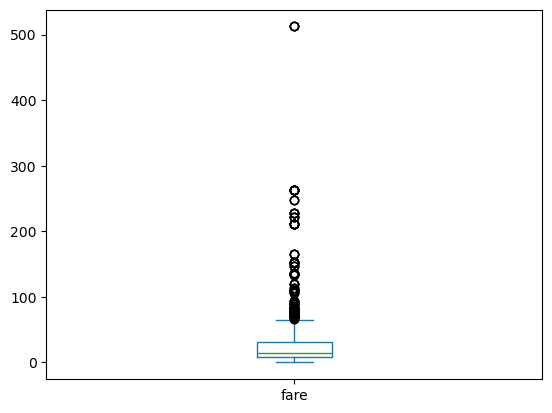

```python
df['fare'].plot(kind='box') # boxplot dla kolumny cena biletu
```

# Wnioski końcowe.

#### Po przeprowadzonej analizie otrzymanych danych pojawiły się następujące wnioski.

#### Dane zawirają informacje dotyczące katastofy statku Titanic. W dostarczonym pliku analizujemy 1310 rekordów w 14 kategoriach: Czy pasażer przeżył katastrofę, Klasa biletu, Imię i nazwisko pasażera, Płeć pasażera, Wiek pasażera, Liczba rodzeństwa/małżonków na pokładzie, Liczba rodziców/dzieci na pokładzie, Numer biletu, Cena biletu, Numer kabiny, Port, w którym pasażer wszedł na pokład, Numer łodzi ratunkowej, Numer ciała, Miejsce docelowe podróży.

## Kluczowe wnioski z analizy:

#### Ceny biletów i wartości odstające: Ceny biletów wykazywały znaczną rozbieżność, a niektóre wartości odstające mogły wynikać z błędnych zapisów lub sumowania cen biletów dla całych rodzin. Średnia cena biletu wynosiła 33,2£.Maksymalna natomiast - 512,3£. Wartości odstające występowały również w danych dotyczących wieku i liczby rodzeństwa/małżonków.

#### Wzorce w danych: Większość pasażerów zaokrętowało się w porcie Southampton, co jest jednym z interesujących wzorców w analizie. Analiza tych danych pozwoliła również na identyfikację błędów w zapisach, takich jak duża liczba brakujących wartości w kolumnach.

### Podsumowując pasażerowie pierwszej klasy i kobiety mieli większe szanse na przeżycie. Jednocześnie mała ilość łodzi jak i nierównomierne rozmieszczenie pasażerów przyczyniły się do małej ilości osób ocalałych.